# NECESIDADES DE IMPLEMENTACIÓN DE AMBIENTES EN EL CAMPUS UTEC

2023-08-31

```r
# install.packages("readr")
# install.packages("ggplot2")
# install.packages("car")
# install.packages("dplyr")
# install.packages("DescTools")
# install.packages("reshape2")
# install.packages("fitdistrplus")
library(ggplot2)
library(reshape2)
library(fitdistrplus)
library(readr)
library(car)
library(dplyr)
library(DescTools)
```

# Introducción

Este trabajo tiene como objetivo principal realizar un análisis estadístico y probabilístico de las preferencias de ambientes por parte de los estudiantes de UTEC, con el fin de identificar las necesidades de implementación de espacios en el nuevo campus de la universidad, ya que según Lazo, S., & Omar, C. (2016) de la Universidad Nacional de Piura la comodidad con el campus universitario influye en el rendimiento académico de los alumnos.

# Relevancia

Este trabajo tiene como objetivo principal realizar un análisis estadístico y probabilístico de las preferencias de ambientes por parte de los estudiantes de UTEC, con el fin de identificar las necesidades de implementación de espacios en el nuevo campus de la universidad.

# Contexto

Actualmente, se encuentra en proceso la construcción de la ampliación del campus UTEC, lo cual ha generado grandes expectativas entre los estudiantes.

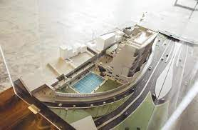

Construcción

# Objetivos

### Objetivo general

Analizar de forma estadística y probabilística la preferencia de ambientes por los estudiantes de UTEC e identificar las necesidades de implementación en el nuevo campus de la UTEC.

## Población, Muestra y Muestreo

- **Población**: Estudiantes de la UTEC en el periodo 2023-1.
- **Muestra**: Se encuestó a aproximadamente 213 estudiantes.
- **Muestreo**: Probabilístico (Muestreo Aleatorio Simple).

## Variables y tipo de variables

| Variable | Tipo |
| --- | --- |
| Sexo | Variable cualitativa nominal |
| Edad | variable cuantitativa discreta |
| Carrera | Variable cualitativa nominal |
| Ciclo | Variable cualitativa ordinal |
| Tiempo en la universidad | variable cuantitativa continua |
| Lugares de preferencia | Variable cualitativa nominal |
| Preferencia de ambientes | Variable cualitativa nominal |
| Tiempo de encontrar lugar de estudio | Variable cuantitativa continua |
| Satisfacción Áreas verdes | Variable cualitativa ordinal |
| Satisfacción Salas de estudio | Variable cualitativa ordinal |
| Satisfacción Biblioteca | Variable cualitativa ordinal |
| Satisfacción Zonas recreativas | Variable cualitativa ordinal |
| Satisfacción laboratorios | Variable cualitativa ordinal |
| Satisfacción cubículos | Variable cualitativa ordinal |
| Tiempo de uso de biblioteca | Variable cuantitativa continua |
| Tiempo de uso de sala de estudio | Variable cuantitativa continua |
| Tiempo de uso espacios recreativos | Variable cuantitativa continua |
| Tiempo de uso cubículos | Variable cuantitativa continua |
| Ambientes de preferencia a implementar | Variable cualitativa nominal |
| Número de áreas verdes | Variable cuantitativa discreta |
| Número de salas de estudio | Variable cuantitativa discreta |
| Número cubículos | Variable cuantitativa discreta |
| Número de zonas recreativas | Variable cuantitativa discreta |

```r
DatosProyecto1 <- read_csv("ESTADÍSTICA BASE DE DATOS (1).csv")
```

```
## -------------------------------------------------------- Delimiter: "," chr
## (6): Sexo, según DNI., ¿Qué carrera estás estudiando actualmente?, ¿Cuá... dbl
## (17): ¿Qué edad tienes ?, ¿En qué ciclo te encuentras actualmente ?, ¿Cu... lgl
## (1): ¿Cree usted que se debería de implementar espacios recreativos?
```

```r
DatosProyecto=DatosProyecto1
DatosProyecto=rename(DatosProyecto,sexo="Sexo, según DNI.",carrera="¿Qué carrera estás estudiando actualmente?",ciclo="¿En qué ciclo te encuentras actualmente ?",tiempou="¿Cuánto tiempo estás en la universidad? (Horas promedio por día) Ejemplo: 5 , 6.30. Determina el decimal con punto.",Edad="¿Qué edad tienes ?",lugar="¿Qué lugares prefieres usar dentro de la universidad?",ambientes="¿Qué ambientes te gustaría que se implementen en el nuevo campus UTEC?",Nrecreativos="¿Cuántos lugares recreativos cree que sería conveniente tener la nueva ampliación de la universidad?",Erecreativos="¿Cree usted que se debería de implementar espacios recreativos?", SSalaE="Salas de estudio (piso 1 y piso11)",SBiblioteca="Biblioteca...13", SAreaVerde="Áreas verdes...11", SZonaR="Zonas recreativas...14", SLaboratorio="Laboratorios", SCubiculos="Cubículos...16",TiempoBuscar="¿Cuánto tiempo te demoras en encontrar un lugar para estudiar? (Horas promedio por día)  (Determina el decimal con un punto ejemplo: 0.5 ,1 , 3)", NAreasVerdes="Áreas verdes...17", NSalaEs="Salas de estudio",NCubiculo="Cubículos...19",NZonaR="Zonas recreativas...20",HoraEspacionR="Espacios recreativos",HoraSalaE="Sala de estudio",HoraCubi="Cubículos...23",HoraBiblio="Biblioteca...24")
DatosProyecto$SAreaVerde <- dplyr::recode(DatosProyecto$SAreaVerde, "1" = "Nada satisfecho", "2" = "Poco satisfecho", "3" = "Medianamente satisfecho", "4" = "Bastante satisfecho", "5" = "Muy satisfecho")
DatosProyecto$SBiblioteca <- dplyr::recode(DatosProyecto$SBiblioteca, "1" = "Nada satisfecho", "2" = "Poco satisfecho", "3" = "Medianamente satisfecho", "4" = "Bastante satisfecho", "5" = "Muy satisfecho")
DatosProyecto$SSalaE<- dplyr::recode(DatosProyecto$SSalaE, "1" = "Nada satisfecho", "2" = "Poco satisfecho", "3" = "Medianamente satisfecho", "4" = "Bastante satisfecho", "5" = "Muy satisfecho")
DatosProyecto$SZonaR<- dplyr::recode(DatosProyecto$SZonaR, "1" = "Nada satisfecho", "2" = "Poco satisfecho", "3" = "Medianamente satisfecho", "4" = "Bastante satisfecho", "5" = "Muy satisfecho")
DatosProyecto$SLaboratorio<- dplyr::recode(DatosProyecto$SLaboratorio, "1" = "Nada satisfecho", "2" = "Poco satisfecho", "3" = "Medianamente satisfecho", "4" = "Bastante satisfecho", "5" = "Muy satisfecho")
DatosProyecto$SCubiculos<- dplyr::recode(DatosProyecto$SCubiculos, "1" = "Nada satisfecho", "2" = "Poco satisfecho", "3" = "Medianamente satisfecho", "4" = "Bastante satisfecho", "5" = "Muy satisfecho")
DatosPLimpios = DatosProyecto
 DatosPLimpios<- DatosPLimpios %>% slice(-2,-1)
DatosPLimpios<- mutate(DatosPLimpios, HoraBiblio=as.numeric(HoraBiblio))
DatosPLimpios<- mutate(DatosPLimpios, tiempou=as.numeric(tiempou))
DatosPLimpios <- DatosPLimpios[DatosPLimpios$tiempou >1 ,]
DatosPLimpios <- DatosPLimpios[DatosPLimpios$TiempoBuscar<4,]
DatosPLimpios <- DatosPLimpios[DatosPLimpios$NAreasVerdes<=10,]
DatosPLimpios <- DatosPLimpios[DatosPLimpios$NSalaEs<11,]
DatosPLimpios <- DatosPLimpios[DatosPLimpios$NCubiculo<=30,]
DatosPLimpios <- DatosPLimpios[DatosPLimpios$NZonaR<=5,]
DatosPLimpios <- DatosPLimpios[DatosPLimpios$HoraEspacionR<=5,]
DatosPLimpios <- DatosPLimpios[DatosPLimpios$HoraSalaE<=5,]
DatosPLimpios <- DatosPLimpios[DatosPLimpios$HoraCubi<=5,]
DatosPLimpios <- DatosPLimpios[DatosPLimpios$HoraBiblio<=5,]
niveles<- c("Nada satisfecho", "Poco satisfecho", "Medianamente satisfecho", "Bastante satisfecho","Muy satisfecho")
DatosPLimpios<- mutate(DatosPLimpios, SAreaVerde=factor(DatosPLimpios$SAreaVerde, levels = niveles),SSalaE=factor(DatosPLimpios$SSalaE, levels = niveles),SBiblioteca=factor(DatosPLimpios$SBiblioteca, levels = niveles),SZonaR=factor(DatosPLimpios$SZonaR, levels = niveles),SLaboratorio=factor(DatosPLimpios$SLaboratorio, levels = niveles),SCubiculos=factor(DatosPLimpios$SCubiculos, levels = niveles))
ciclo_orden <-c(1,2,3,4,5,6,7,8,9,10)
DatosPLimpios<- mutate(DatosPLimpios, ciclo=factor(ciclo, levels = ciclo_orden))
table(DatosPLimpios$ciclo)
```

```
##
##  1  2  3  4  5  6  7  8  9 10
## 12 40 21 21 25 12  6  5  4  4
```

```r
DatosPLimpios$sexo = recode(DatosPLimpios$sexo, 'F'='Femenino', 'M'='Masculino')
```

# ANÁLISIS DESCRIPTIVO

OJO: En esta entrega solo se están presentando las principales gráficas del análisis descriptivo.

### Primero analizaremos brevemente con gráficas la distribución de la muestra que tenemos según sexo, edad y carrera:

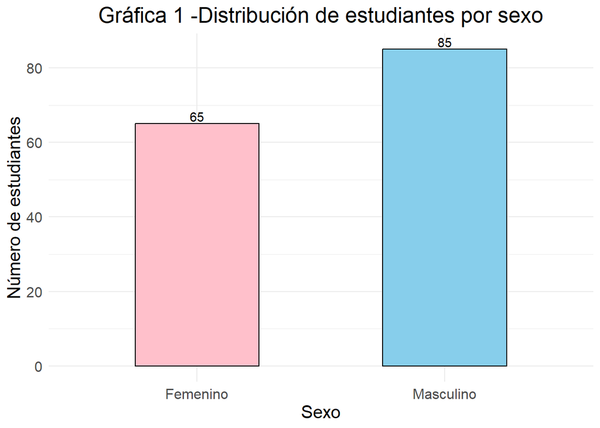

```r
# Asumiendo que tu data frame se llama DatosPLimpios

# Crear la gráfica
p <- ggplot(DatosPLimpios, aes(x=sexo, fill=sexo))

# Añadir capas de gráficas: barras y texto
p + geom_bar(color="black", width = 0.5) +
  geom_text(stat='count', aes(label=..count..), vjust=-0.25) +
  scale_fill_manual(values = c("Femenino" = "pink", "Masculino" = "skyblue")) +
  theme_minimal() +
  labs(x="Sexo", y="Número de estudiantes", title="Gráfica 1 -Distribución de estudiantes por sexo") +
  theme(plot.title = element_text(hjust = 0.5),
        text = element_text(size=15),
        legend.position = "none")
```

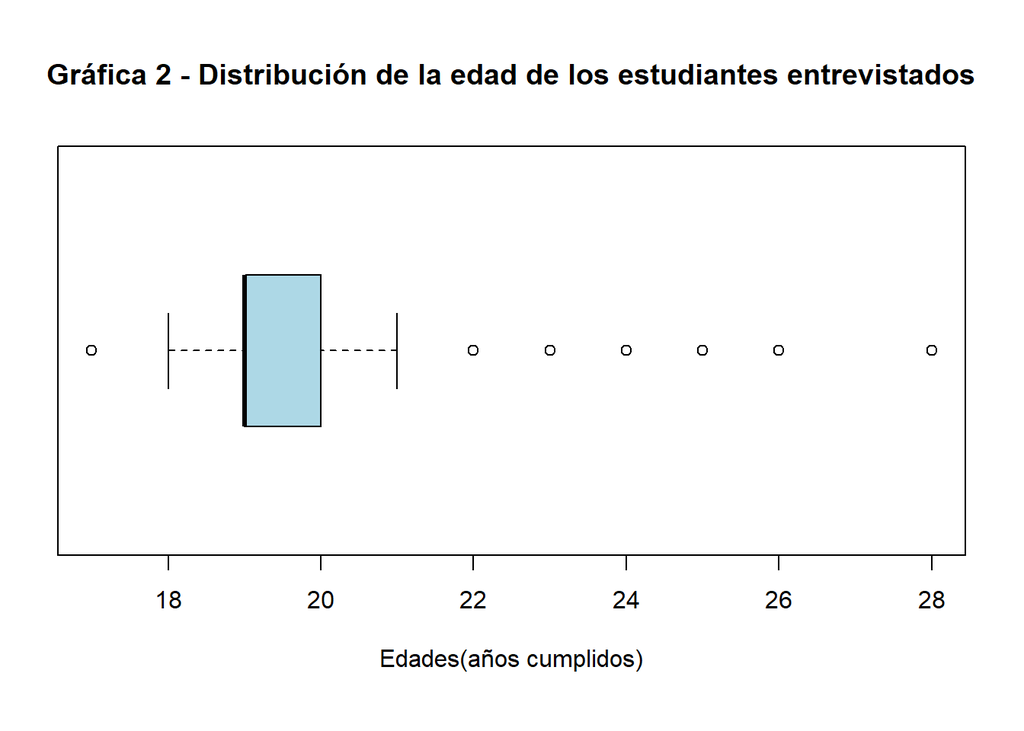

```r
#se hace el boxplot y el summary
par(mar = c(6, 2, 5, 2))
boxplot(DatosPLimpios$Edad, horizontal = TRUE, main="Gráfica 2 - Distribución de la edad de los estudiantes entrevistados",xlab="Edades(años cumplidos)",col="lightblue")
```

```r
summary(DatosPLimpios$Edad)
```

```
##    Min. 1st Qu.  Median    Mean 3rd Qu.    Max.
##   17.00   19.00   19.00   19.79   20.00   28.00
```

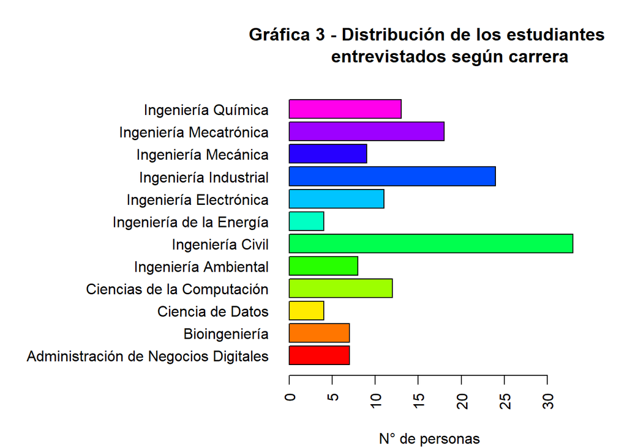

```r
C <- table(DatosPLimpios$carrera)
#se hace el gráfico de barras
par(mar = c(4, 16, 5, 3)) # Determinante de margen
barplot(C,las=2,horiz= TRUE,cex.names = 1, col = rainbow(13),  main="Gráfica 3 - Distribución de los estudiantes
        entrevistados según carrera", xlab="N° de personas")
```

```r
table(DatosPLimpios$carrera)
```

```
##
## Administración de Negocios Digitales                        Bioingeniería
##                                    7                                    7
##                     Ciencia de Datos           Ciencias de la Computación
##                                    4                                   12
##                 Ingeniería Ambiental                     Ingeniería Civil
##                                    8                                   33
##             Ingeniería de la Energía               Ingeniería Electrónica
##                                    4                                   11
##                Ingeniería Industrial                  Ingeniería Mecánica
##                                   24                                    9
##               Ingeniería Mecatrónica                   Ingeniería Química
##                                   18                                   13
```

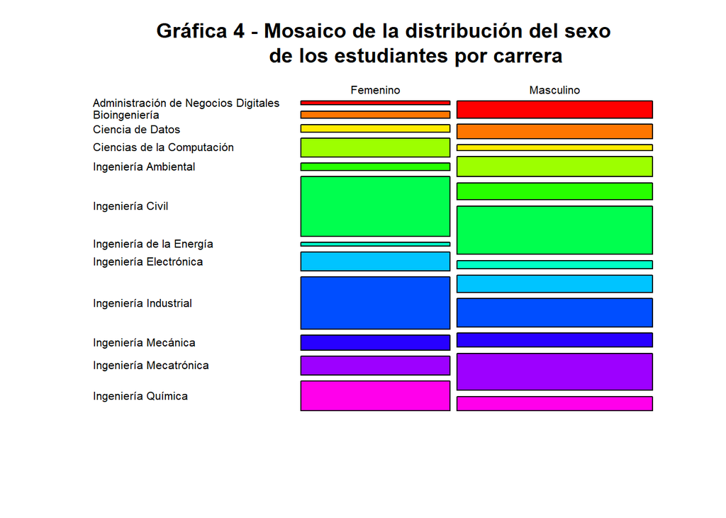

## Análisis del tiempo que los alumnos pasan en la universidad y los espacios que prefieren para estudiar

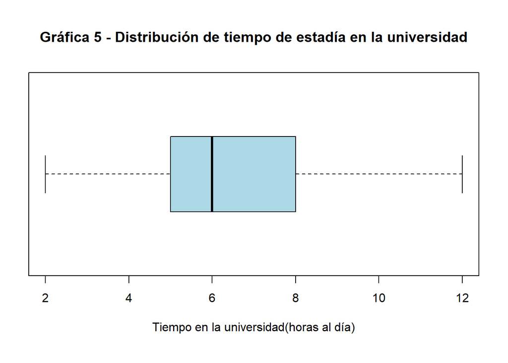

```
##    Min. 1st Qu.  Median    Mean 3rd Qu.    Max.
##   2.000   5.000   6.000   6.719   8.000  12.000
```

## Análisis del tiempo que los alumnos pasan en la universidad

```
## [1] 3
```

[output not shown]

```
##  75%
## 12.5
```

## Preferencia de ambientes a implementar en el nuevo campus

#### Creamos una función para analizar las variables con opción múltiple

```r
contar_lugares = function(lugares_preferidos) {
  lugares_completo = c()
  for(lugares in lugares_preferidos){
    lugares_lista = strsplit(lugares, ", ")[[1]]
    for(lugar in lugares_lista){
      lugares_completo = append(lugares_completo, lugar)
    }
  }
  return(lugares_completo)
}

#se usa la funcion contar_lugares para extraer todos los lugares preferidos
lugares_preferidos = contar_lugares(DatosProyecto$lugar)
```

```
## lugares_preferidos
##                Áreas verdes Auditorio de la universidad
##                          63                          30
##                        Aula                  Biblioteca
##                         107                         104
##   Bloques de madera -Piso 6                   Cubículos
##                          37                         129
##    Sala de Estudios - Piso1   Sala de Estudios - Piso11
##                          41                          71
##           Zonas recreativas
##                          26
```

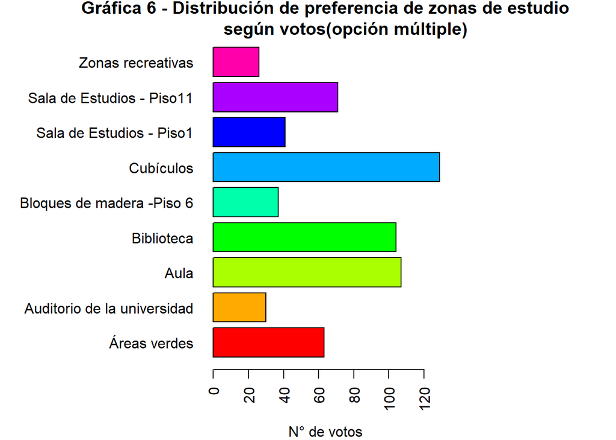

```
## lugares_deseados
##              Áreas verdes                 Auditorio                     Aulas
##                        81                        23                        38
##                Biblioteca           Campo deportivo                   Comedor
##                        37                        78                        32
## Comedor con comida rápida                 Cubículos                  Gimnasio
##                        45                        89                       110
##              laboratorios          Salas de estudio         Zonas recreativas
##                        52                        77                        71
```

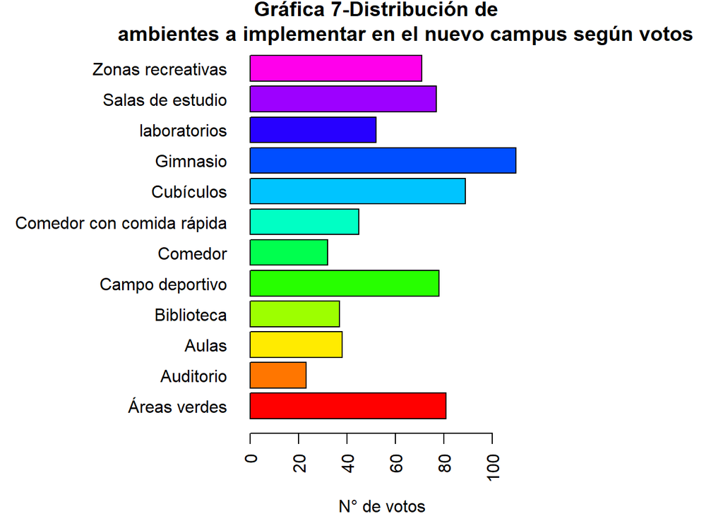

```
## [1] 110
```

## Análisis de tiempo que les toma a los estudiantes buscar un lugar de estudio dentro del campus UTEC

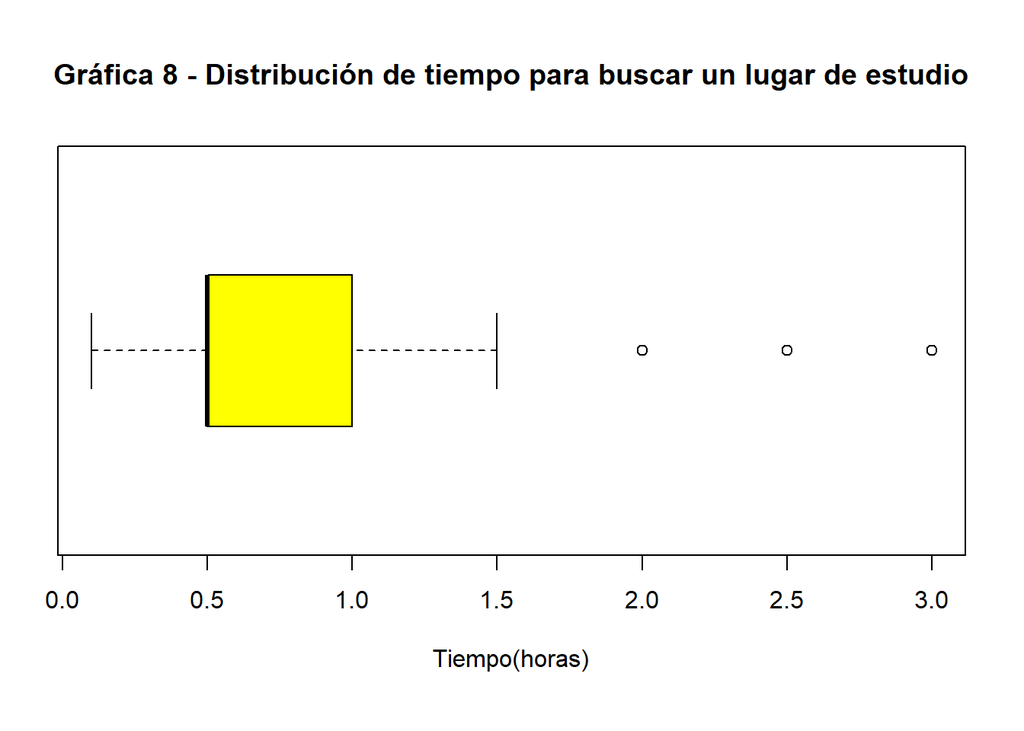

```
##    Min. 1st Qu.  Median    Mean 3rd Qu.    Max.
##    0.10    0.50    0.50    0.77    1.00    3.00
```

## Análisis de satisfacción de los alumnos con los principales ambientes de la UTEC

### Satisfacción de biblioteca

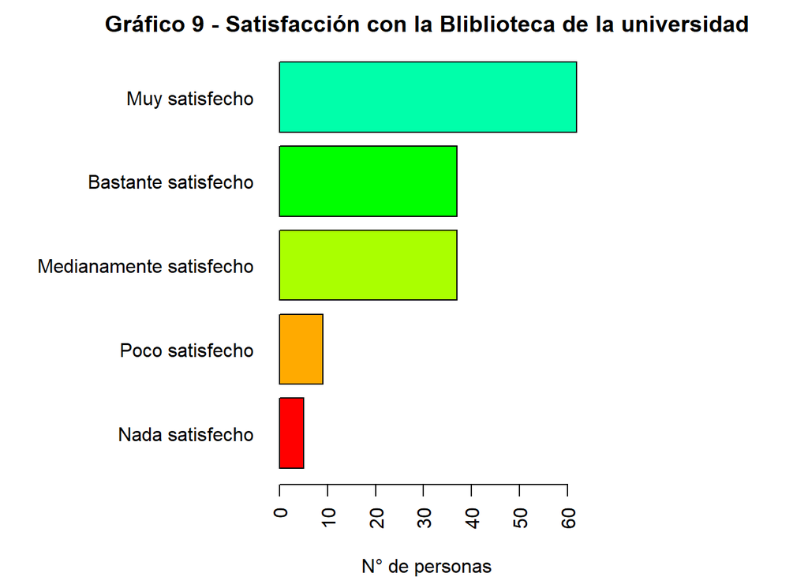

### Satisfacción de cubículos

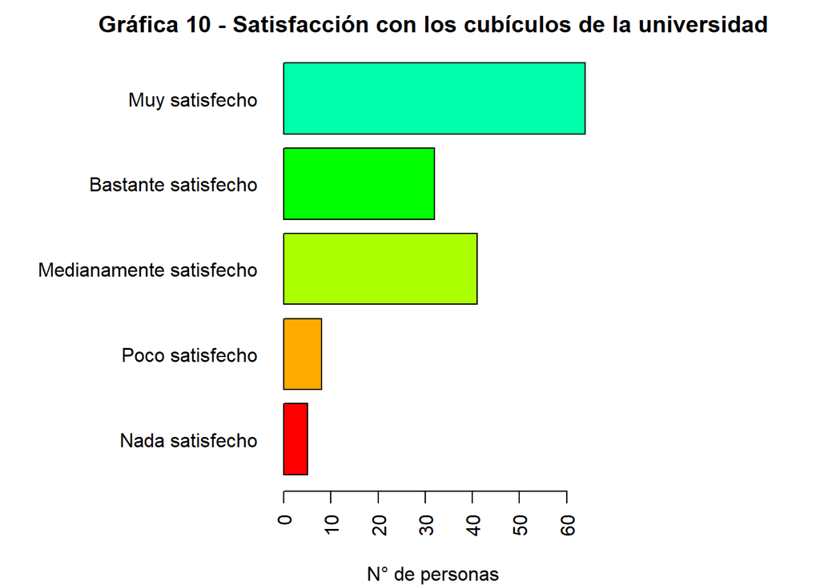

### Satisfacción de los alumnos con el cubículo en relación al ciclo al que pertenecen

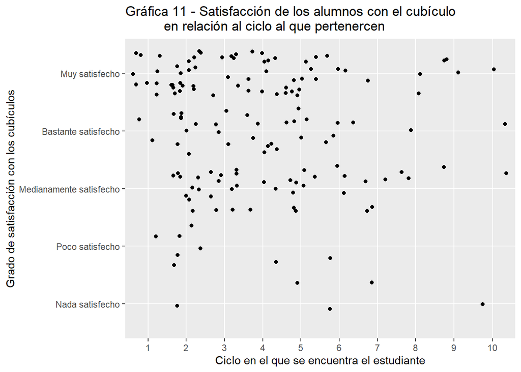

##Se analiza el uso de los espacios

```
## $breaks
##  [1] 0.0 0.5 1.0 1.5 2.0 2.5 3.0 3.5 4.0 4.5 5.0
##
## $counts
##  [1] 14 43  1 69  0  7  0  8  1  7
##
## $density
##  [1] 0.18666667 0.57333333 0.01333333 0.92000000 0.00000000 0.09333333
##  [7] 0.00000000 0.10666667 0.01333333 0.09333333
##
## $mids
##  [1] 0.25 0.75 1.25 1.75 2.25 2.75 3.25 3.75 4.25 4.75
##
## $xname
## [1] "DatosPLimpios$HoraCubi"
##
## $equidist
## [1] TRUE
##
## attr(,"class")
## [1] "histogram"
```

```
##  [1] 0.00 0.25 0.75 1.25 1.75 2.25 2.75 3.25 3.75 4.25 4.75 5.00
```

```
##  [1]  0 14 43  1 69  0  7  0  8  1  7  0
```

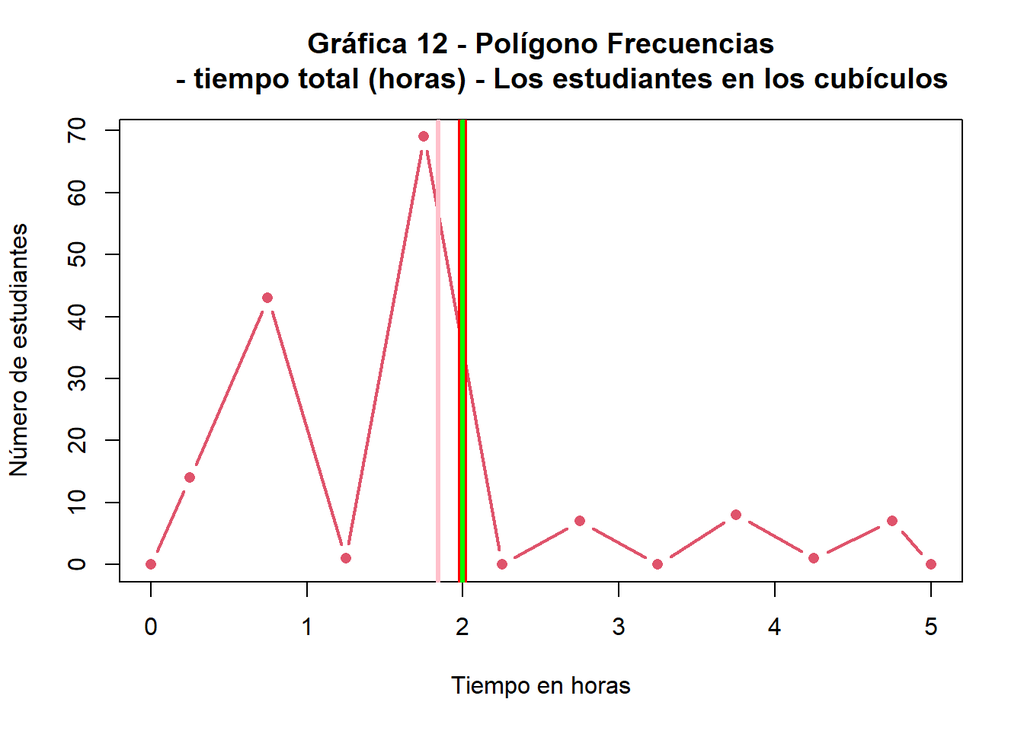

```
##    Min. 1st Qu.  Median    Mean 3rd Qu.    Max.
##   0.000   1.000   2.000   1.843   2.000   5.000
```

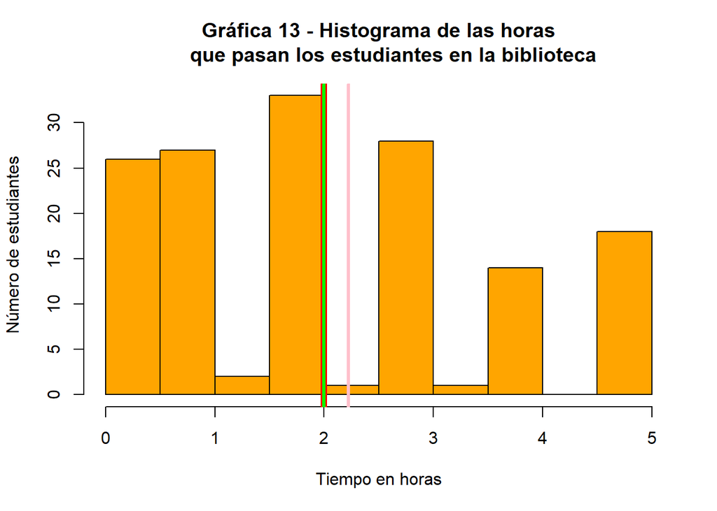

```
##    Min. 1st Qu.  Median    Mean 3rd Qu.    Max.
##   0.000   1.000   2.000   2.223   3.000   5.000
```

##Analizamos el número de espacios que es necesario implementar en el nuevo campus

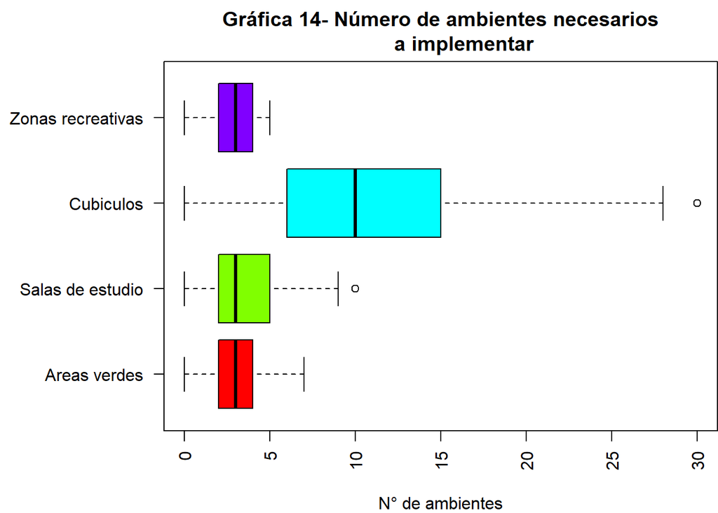

```
##    Min. 1st Qu.  Median    Mean 3rd Qu.    Max.
##    0.00    2.00    3.00    3.04    4.00    7.00
```

```
##    Min. 1st Qu.  Median    Mean 3rd Qu.    Max.
##   0.000   2.000   3.000   3.387   5.000  10.000
```

```
##    Min. 1st Qu.  Median    Mean 3rd Qu.    Max.
##    0.00    6.00   10.00   10.73   15.00   30.00
```

```
##    Min. 1st Qu.  Median    Mean 3rd Qu.    Max.
##    0.00    2.00    3.00    2.82    4.00    5.00
```

```
## [1] 1.380011
```

```
## [1] 2.173009
```

```
## [1] 6.830544
```

```
## [1] 1.311129
```

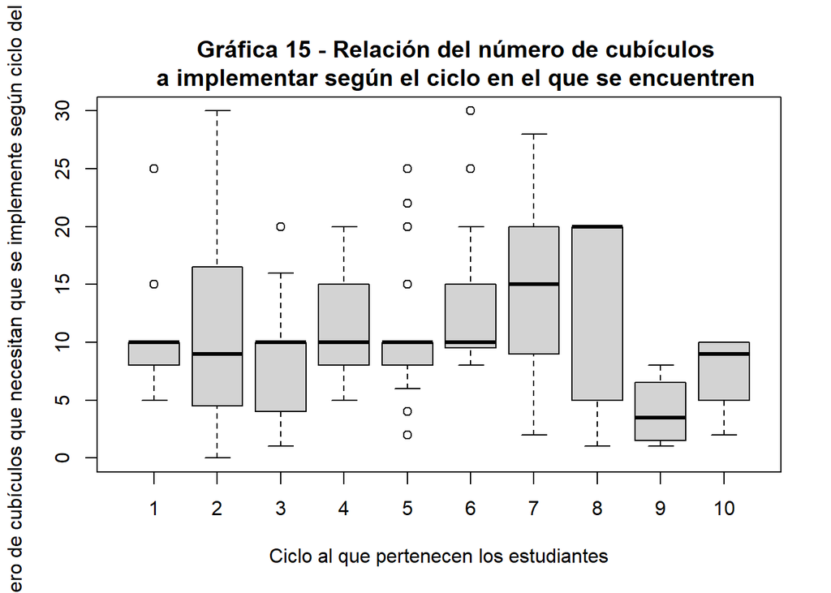

# ANÁLISIS PROBABILÍSTICO

### Diagrama de Gantt

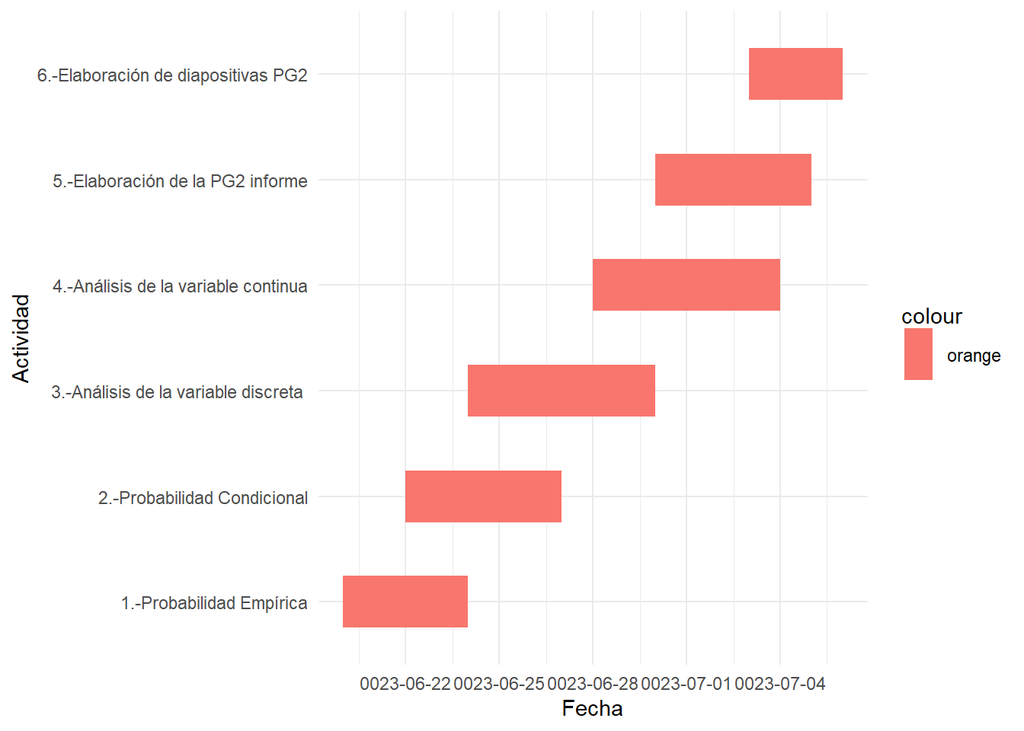

```r
# Crea un conjunto de datos de ejemplo
datos <- data.frame(
  Actividad = c("1.-Probabilidad Empírica", "2.-Probabilidad Condicional", "3.-Análisis de la variable discreta ","4.-Análisis de la variable continua", "5.-Elaboración de la PG2 informe","6.-Elaboración de diapositivas PG2"),
  Inicio = as.Date(c("23-06-20", "23-06-22","23-06-24","23-06-28","23-06-30","23-07-03")),
  Fin = as.Date(c("23-06-24", "23-06-27","23-06-30","23-07-04","23-07-05","23-07-06"))
)

# Calcula la duración de cada tarea
datos$Duracion <- as.numeric(datos$Fin - datos$Inicio)

# Crea el diagrama de Gantt utilizando ggplot2
ggplot(datos, aes(col="orange",x = Inicio, xend = Fin, y = Actividad, yend = Actividad)) +
  geom_segment(size = 12) +
  geom_text(aes(x = Inicio + Duracion/10, label = Duracion)) +
  scale_x_date(date_breaks = "3 day", date_labels = "%Y-%m-%d") +
  labs(x = "Fecha", y = "Actividad") +
  theme_minimal()
```

## Objetivos:

1. Analizar probabilísticamente el tiempo de estadía de un estudiante en el campus de UTEC.
2. Analizar la probabilidad del tiempo que se demora un estudiante de UTEC en buscar un lugar de estudio.
3. Analizar la probabilidad del tiempo de estadía de un estudiante de UTEC en la biblioteca.
4. Analizar probabilísticamente la relación de búsqueda de un espacio para estudiar con el tiempo que pasan los alumnos en la universidad.

## Probabilidad Empírica

En nuestro estudio, analizamos el **tiempo que les toma a los alumnos de la UTEC encontrar un espacio para estudiar**

**Experimento aleatorio**: Seleccionar un estudiante de los 150 encuestados y analizar el tiempo (en horas) que les toma encontrar un espacio para estudiar.

**Muestra**: 150 alumnos de la UTEC seleccionados por muestreo aleatorio simple.

**Eventos**:

A: Si se demora de 0.1 a 0.6 horas en buscar un espacio para estudiar.
$$P(A) = \frac{93}{150} =
0.62000000$$
B: Si se demora más de 0.6 a 1.1 horas en buscar un espacio para estudiar.
$$P(B) =
\frac{40}{150} = 0.26666667$$
C: Si se demora más de 1.1 a 1.6 horas en buscar un espacio para estudiar.
$$P(C) = \frac{6}{150} = 0.04000000$$
D: Si se demora más de 1.6 a 2.1 horas en buscar un espacio para estudiar.
$$P(D) = \frac{5}{150} = 0.03333333$$
E: Si se demora más de 2.1 a 2.6 horas en buscar un espacio para estudiar.
$$P(E) = \frac{2}{150} =
0.01333333$$

```
## # A tibble: 6 x 3
##   TiempoBuscar_intervalo     n Probabilidad
##   <fct>                  <int>        <dbl>
## 1 [0.1,0.6]                 93       0.62
## 2 (0.6,1.1]                 40       0.267
## 3 (1.1,1.6]                  6       0.04
## 4 (1.6,2.1]                  5       0.0333
## 5 (2.1,2.6]                  2       0.0133
## 6 <NA>                       4       0.0267
```

En nuestro estudio, analizamos el **tiempo que los alumnos pasan en la biblioteca de la universidad**

**Experimento aleatorio** : Seleccionar un estudiante de los 150 encuestados y analizar el tiempo (en horas) que pasan en la biblioteca de la UTEC.

**Muestra**: 150 alumnos de la UTEC seleccionados por muestreo aleatorio simple.

**Espacio muestral**: Ω = [0;5]

Eventos:

A: Si pasa de 0.1 a 1 hora en la biblioteca de la universidad.
$$P(A) = \frac{53}{150} = 0.3533333$$

B: Si pasa más de 1, hasta 2 horas en la biblioteca de la universidad.
$$P(B) = \frac{35}{150} =
0.2333333$$

C: Si pasa más de 2, hasta 3 horas en la biblioteca de la universidad.
$$P(C) = \frac{29}{150} =
0.1933333$$

D: Si pasa más de 3, hasta 4 horas en la biblioteca de la universidad.
$$P(D) = \frac{15}{150} =
0.1000000$$

E: Si pasa más de 4, hasta 5 horas en la biblioteca de la universidad.
$$P(E) = \frac{18}{150} =
0.1200000$$

```
## # A tibble: 5 x 3
##   HorasBiblio_intervalo     n Probabilidad
##   <fct>                 <int>        <dbl>
## 1 [0,1]                    53        0.353
## 2 (1,2]                    35        0.233
## 3 (2,3]                    29        0.193
## 4 (3,4]                    15        0.1
## 5 (4,5]                    18        0.12
```

Estos resultados sugieren que la mayoría de los estudiantes de la UTEC utilizan la biblioteca por períodos de tiempo relativamente cortos. Sin embargo, hay una proporción significativa de estudiantes que pasan varias horas en la biblioteca, lo que indica que la biblioteca es un recurso importante para el estudio y el aprendizaje.

## Probabilidad Condicional

Para verificar si dos eventos son independientes, necesitamos comprobar si la probabilidad de que ocurra un evento es la misma independientemente de si el otro evento ocurre o no. En términos de probabilidad condicional, esto se traduce en la siguiente igualdad:

P(A|B) = P(A)

Si esta igualdad se cumple, entonces podemos decir que los eventos A y B son independientes. Si no se cumple, entonces los eventos son dependientes.

En el contexto del estudio, podríamos definir los siguientes eventos:

Evento A: Un estudiante pasa cierto número de horas en la biblioteca. Evento B: Un estudiante pasa cierto tiempo buscando un espacio para estudiar. Para verificar si estos eventos son independientes, necesitaríamos calcular la probabilidad condicional de A dado B (P(A|B)) y la probabilidad de A (P(A)), y luego compararlas.

```
## # A tibble: 24 x 10
##    HorasBiblio_intervalo TiempoBuscar_intervalo   n.x Probabilidad_Conjunta
##    <fct>                 <fct>                  <int>                 <dbl>
##  1 [0,1]                 [0.1,0.6]                 34               0.227
##  2 [0,1]                 (0.6,1.1]                 14               0.0933
##  3 [0,1]                 (1.1,1.6]                  2               0.0133
##  4 [0,1]                 (1.6,2.1]                  2               0.0133
##  5 [0,1]                 <NA>                       1               0.00667
##  6 (1,2]                 [0.1,0.6]                 19               0.127
##  7 (1,2]                 (0.6,1.1]                 12               0.08
##  8 (1,2]                 (1.1,1.6]                  1               0.00667
##  9 (1,2]                 (1.6,2.1]                  1               0.00667
## 10 (1,2]                 (2.1,2.6]                  1               0.00667
## # i 14 more rows
## # i 6 more variables: n.y <int>, Probabilidad_TiempoBuscar <dbl>,
## #   Probabilidad_Condicional <dbl>, n <int>, Probabilidad_HorasBiblio <dbl>,
## #   Son_independientes <lgl>
```

El análisis de probabilidad condicional puede ser una forma efectiva de descubrir relaciones entre variables entre nuestros datos. Podemos hallar la probabilidad condicional siguiente manera:

P(A|B) = P(A ∩ B) / P(B)

Esto se lee como “la probabilidad de A dado B es igual a la probabilidad de A y B dividida por la probabilidad de B”. En otras palabras, estamos buscando la probabilidad de que ocurra un evento (A) dado que ya sabes que otro evento (B) ha ocurrido.

En este caso estamos interesados en la probabilidad condicional de que un estudiante pase más de 6 horas en la UTEC dado que pasa más de una hora buscando un lugar para estudiar.

Para realizar esto, procederemos con el análisis. Primero calcularemos la probabilidad de cada evento

```r
# Crea un subconjunto para los estudiantes que pasan más de una hora buscando un lugar para estudiar
# Crea un subconjunto para los estudiantes que pasan más de 6 horas en UTEC
tiempou_mayor_6 <- DatosPLimpios$tiempou > 6

tiempo_buscar_mayor_1 <- DatosPLimpios$TiempoBuscar > 1
# Calcula la probabilidad de cada evento
prob_tiempo_buscar_mayor_1 <- mean(tiempo_buscar_mayor_1)
prob_tiempou_mayor_6 <- mean(tiempou_mayor_6)
```

$A$ es el evento de que un estudiante pase más de 6 horas en la UTEC. $B$ es el evento de que un estudiante pase más de una hora buscando un lugar para estudiar.

Ahora calcularemos la probabilidad conjunta y condicional.

$$ \ \ P(A) = 0.493\ P(B) = 0.113\ P(AB) = 0.053\ P(A | B) = 0.471 $$ P(A) = 0.493: Esta es la probabilidad de que un estudiante pase más de 6 horas en UTEC. Esto indica que aproximadamente la mitad de los estudiantes pasa más de 6 horas en UTEC, lo que sugiere que los estudiantes pueden pasar mucho tiempo en la universidad, ya sea estudiando, asistiendo a clases o participando en otras actividades.

P(B) = 0.113: Esta es la probabilidad de que un estudiante pase más de una hora buscando un lugar para estudiar. Esto indica que sólo alrededor del 11% de los estudiantes pasan más de una hora buscando un lugar para estudiar. Esto podría indicar que la mayoría de los estudiantes tienen un lugar preferido para estudiar o que la universidad tiene suficientes espacios de estudio para acomodar a los estudiantes.

P(A $\cap$ B) = 0.053: Esta es la probabilidad de que un estudiante pase más de 6 horas en UTEC y más de una hora buscando un lugar para estudiar. Aproximadamente el 5% de los estudiantes caen en esta categoría. Esta es una fracción bastante pequeña de los estudiantes, lo que indica que estos dos comportamientos no suelen ocurrir simultáneamente.

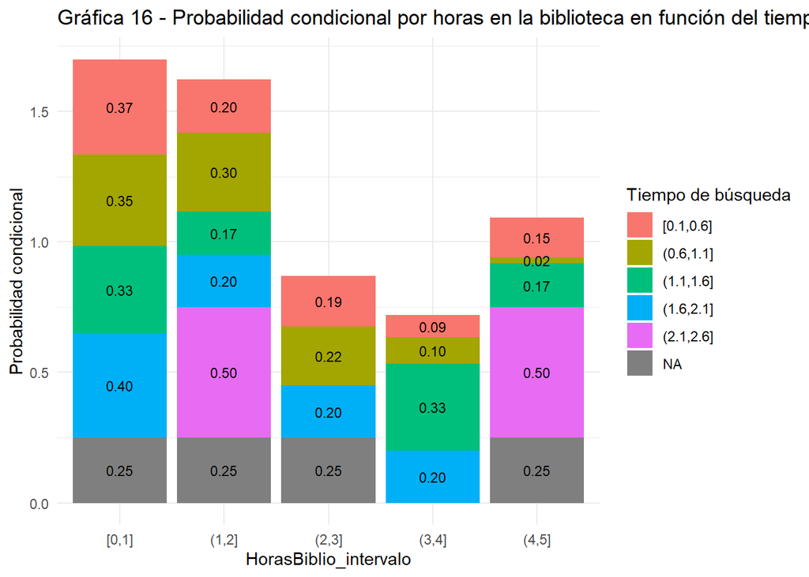

```r
# Crear el gráfico
library(ggplot2)

df <- data.frame(
  HorasBiblio_intervalo = prob_condicional_marginal$HorasBiblio_intervalo,
  TiempoBuscar_intervalo = prob_condicional_marginal$TiempoBuscar_intervalo,
  Probabilidad_Condicional = prob_condicional_marginal$Probabilidad_Condicional,
  Probabilidad_HorasBiblio = prob_condicional_marginal$Probabilidad_HorasBiblio
)

ggplot(df, aes(x=HorasBiblio_intervalo, y=Probabilidad_Condicional, fill=TiempoBuscar_intervalo))+
  geom_bar(stat="identity") +
  geom_text(aes(label=sprintf("%.2f", Probabilidad_Condicional)), position=position_stack(vjust=0.5), size=3) +
  ylab("Probabilidad condicional") +
  labs(title="Gráfica 16 - Probabilidad condicional por horas en la biblioteca en función del tiempo de búsqueda")+
  theme_minimal() +
  labs(fill = "Tiempo de búsqueda")
```

## Variables Aleatorias Discretas

### Preferencia de Lugar

Ahora procederemos a analizar la variable de preferencia de lugar. Esta variable es particularmente importante para nuestro estudio debido a que expresa la preferencia de los estudiantes a la hora de buscar un lugar para estudiar. La variable muestra la preferencia de los estudiantes de acuerdo a los votos.

```
## primer_lugar
##              Áreas verdes                      Aula                Biblioteca
##                         3                        41                        70
## Bloques de madera -Piso 6                 Cubículos  Sala de Estudios - Piso1
##                         1                        20                         9
## Sala de Estudios - Piso11
##                         6
```

Como podemos ver, la biblioteca es el lugar favorito de los estudiantes y luego le siguen las aulas vacías. En este caso, queremos saber la probabilidad de que un estudiante elija la biblioteca como primera opción para estudiar. Como el evento escoger la biblioteca es excluyente de los demás eventos (un estudiante no puede tener dos primeras opciones), podemos usar probabilidad empírica para formar un proceso Bernoulli.

Definiremos los parámetros de nuestra variable aleatoria como:
$$\text{Definimos A como la elección de la biblioteca un estudiante como
lugar preferido para estudiar }\\
\text{Siendo p = P(A) = Probabilidad de que un estudiante encuestado
escogido al azar responda como lugar favorito la biblioteca }\\
\text{q = 1-p}$$
Definiremos el éxito como la elección de la biblioteca como éxito y le asignaremos 1 a este éxito; 0 al fracaso. Siendo caracterizada de esta forma.

Definimos la variable aleatoria Y como:
$$Y \sim \text{ Variable aleatoria que representa la elecciòn de un
estudiante al azar }\\
Y =
\begin{cases}
1 & \text{si el estudiante elige la biblioteca} \\
0 & \text{si el estudiante elige cualquier otro lugar}
\end{cases}
\\Y \sim Bernulli(p=0.4667)$$

```
## La probabilidad de que un estudiante escoja la biblioteca como primera opcion es: 0.4666667
```

Ahora supongamos que tenemos n estudiantes y cada estudiante elige de manera independiente si su lugar preferido para estudiar es la biblioteca (con probabilidad p) o no. Entonces, podemos definir una nueva variable aleatoria X, que es el número total de estudiantes que eligen la biblioteca como su lugar favorito para estudiar. Esta sigue una distribución binomial con parámetros n y p.

Una distribución binomial se puede considerar como la suma de n variables aleatorias independientes, cada una de las cuales sigue una distribución de Bernoulli. Si tienes una variable aleatoria X que sigue una distribución de Bernoulli con parámetro p (Y ~ Bernoulli(p)), entonces la suma de n de estas variables aleatorias independientes seguirá una distribución binomial.

$$X \sim \text{ Número de estudiantes que eligen la biblioteca como lugar
favorito para estudiar }\\
X \sim \text{Binomial}(n, p)$$

Una vez que se tiene la variable aleatoria X definida de esta manera, podemos calcular varias cantidades de interés. Por ejemplo, se puede calcular la probabilidad de que exactamente k estudiantes elijan la biblioteca como su lugar preferido para estudiar utilizando la función de probabilidad de la distribución binomial:

$$P(X = k) = \binom{n}{k} p^k (1-p)^{n-k}$$

#### Preguntas importantes

Asumiendo que la encuesta es representativa, podemos hacer el siguiente análisis:

Si le preguntamos a 10 estudiantes si la biblioteca es su lugar preferido, determinamos la probabilidad de que 6 o más nos digan que la biblioteca es su lugar favorito para estudiar.

#### Caracterizando la variable aleatoria

$$P(X \geq 6) = 1 - P(X \leq 5)\\
Siendo\ X \sim \text{Binomial}(10, 0.4667)$$

Como sabemos, la distribución binomial es una distribución de probabilidad discreta que nos indica el porcentaje en que es probable obtener un resultado entre dos posibles al realizar un número n de pruebas.

En este caso haremos 10 ensayos (10 encuestados) y contaremos la cantidad de positivos.

```r
cat("La probabilidad de que 6 de 10 estudiantes respondan que la biblioteca es su lugar favorito es:",pbinom(5,10,probabilidad_biblioteca,lower.tail = FALSE))
```

```
## La probabilidad de que 6 de 10 estudiantes respondan que la biblioteca es su lugar favorito es: 0.2981162
```

Podemos graficar la función de probabilidad.

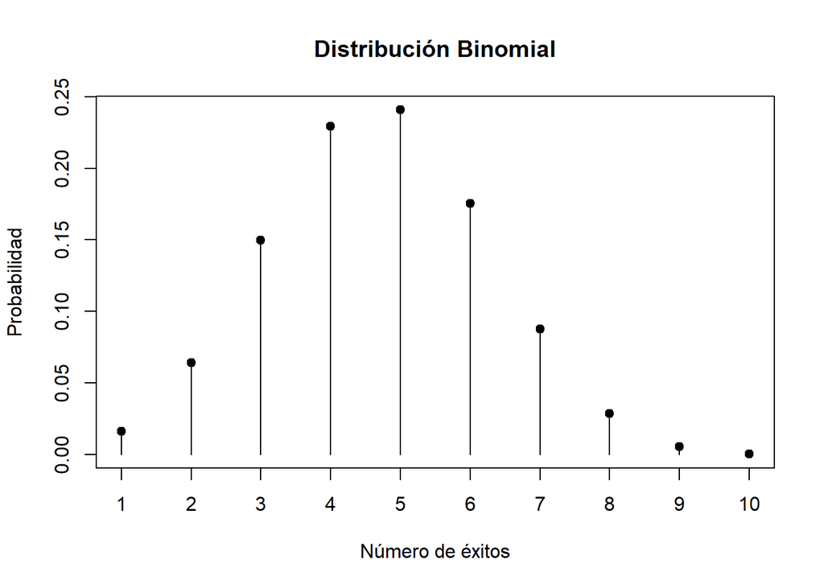

## Variables aleatorias continuas

### Tiempo en buscar un lugar para estudiar

La primera variable a analizar probabilísticamente es TiempoBuscar. Esta variable modela el tiempo que un estudiante se demora en encontrar un lugar o espacio para estudiar. Por teoría, sabemos que los tiempos entre llegadas se pueden modelar como una variable aleatoria exponencial. Haremos un histograma para analizar gráficamente esta variable y determinar si se aproxima a una variable aleatoria exponencial.

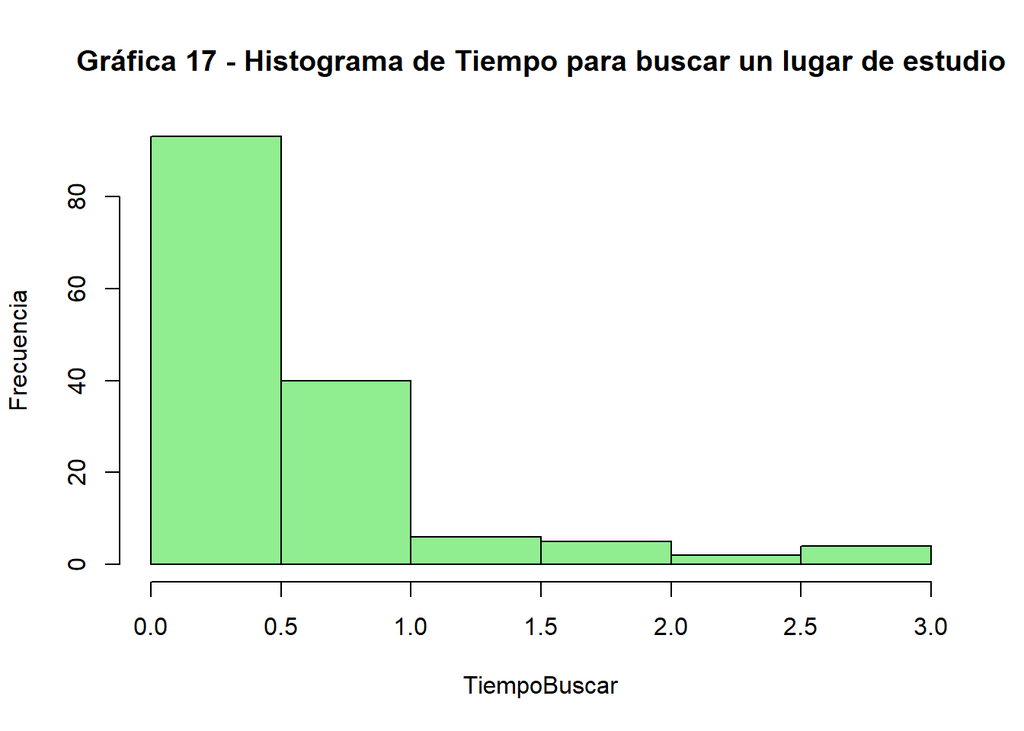

Como podemos observar, la variable se parece a una distribución exponencial. Ahora buscaremos caracterizar la variable como una distribución exponencial.

#### Caracterizando la variable

El único parámetro de una distribución exponencial es la media.

```
## La media de Tiempo Buscar es: 0.7686667 horas.
```

Usaremos este valor para generar numeros que sigan esta distribucion para asi compararla graficamente con esta variable.

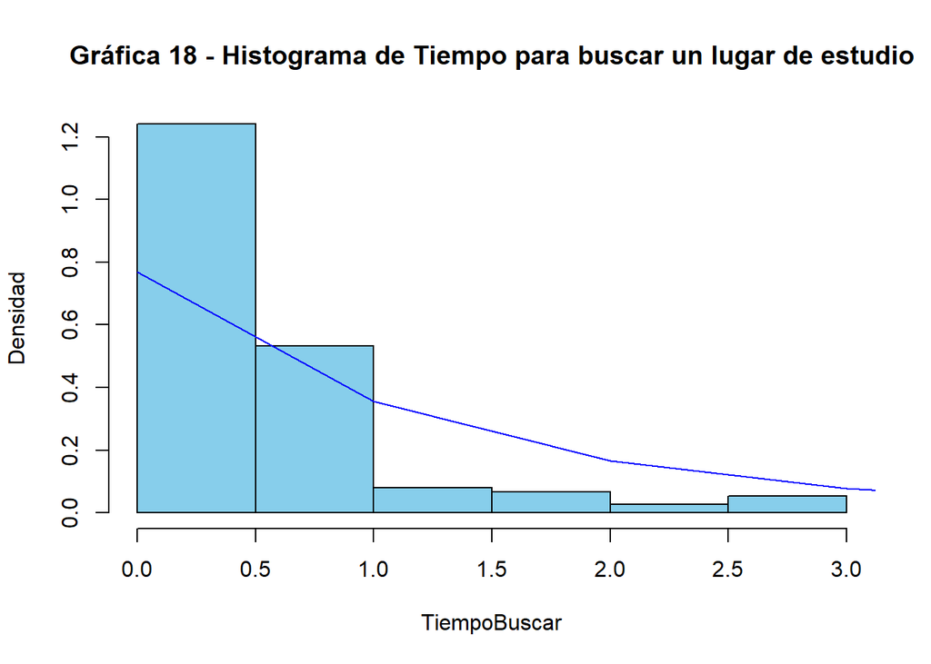

Ahora, para comprobar finalmente que la variable se puede modelar con una distribución exponencial, usaremos el gráfico **Cullen y Frey**. Este gráfico compara la curtosis y simetría de las variables más conocidas y nos da una estimación comparada a nuestra variable.

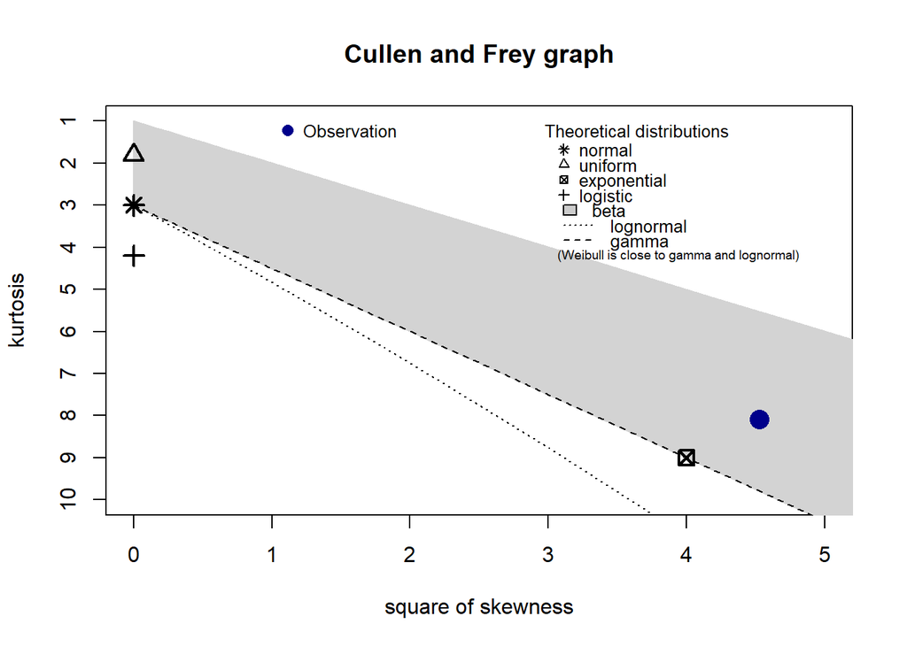

```
## summary statistics
## ------
## min:  0.1   max:  3
## median:  0.5
## mean:  0.7686667
## estimated sd:  0.5804577
## estimated skewness:  2.127204
## estimated kurtosis:  8.091143
```

#### Preguntas Importantes

Analizamos la probabilidad de que un estudiante en UTEC pase mas de 1 hora buscando un lugar para estudiar.

```
## La probabilidad de que un estudiante en UTEC pase mas de una hora buscando lugar para estudiar es 0.4636308
```

### Tiempo en la Universidad

El tiempo que un estudiante pasa en la universidad es importante para determinar el uso de los ambientes dentro de UTEC. Haremos el ajuste de esta distribución primero haciendo un análisis visual.

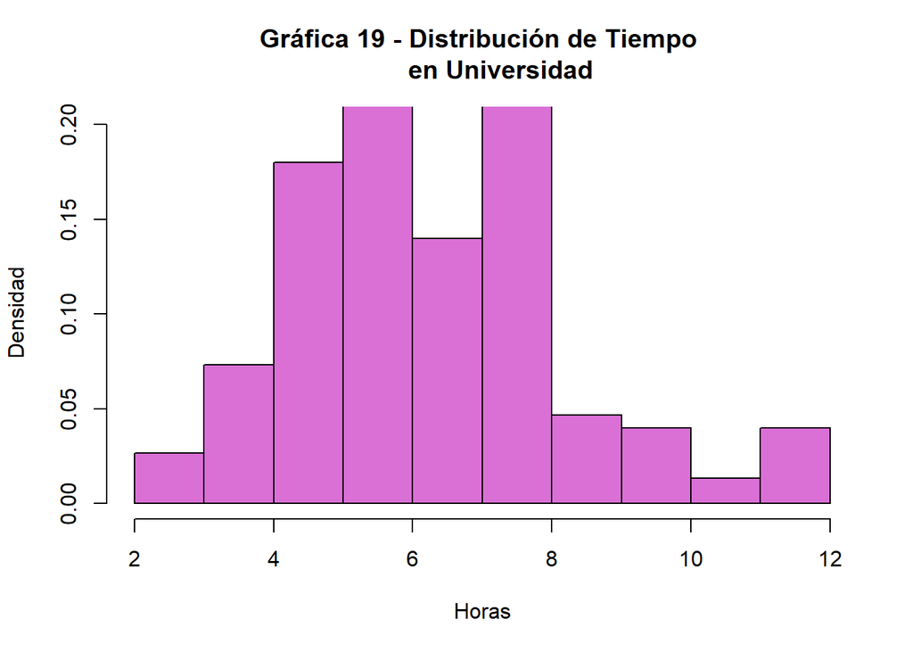

#### Caracterización de la variable

Ahora que podemos sospechar que la variable horas en la universidad se asemeja a una distribución normal, podemos hacer un gráfico con la curva de densidad teórica basada en la media y la desviación estándar de nuestros datos.

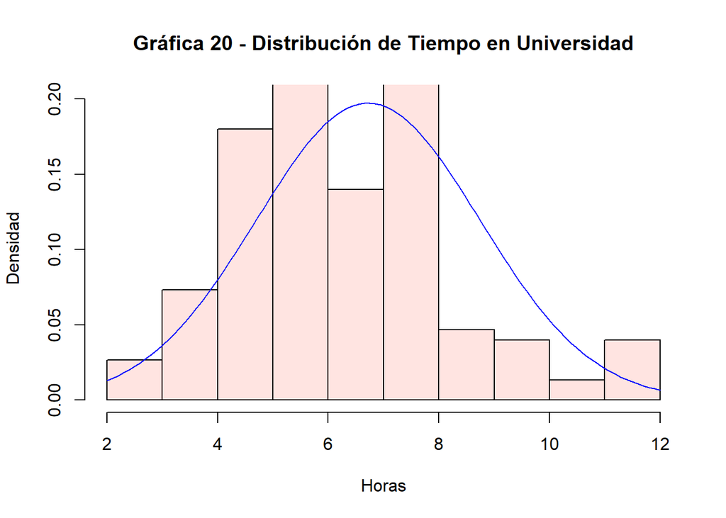

Para asegurarnos de que nuestros datos se asemejan a una distribución normal, vamos a realizar un gráfico Cullen and Frey para analizar la simetría y la curtosis y compararla con una de una distribución normal

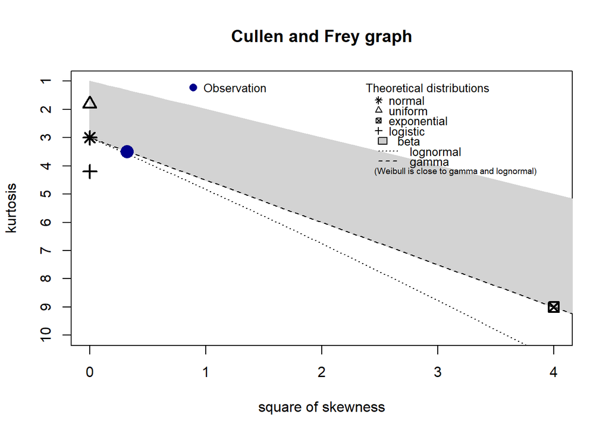

```
## summary statistics
## ------
## min:  2   max:  12
## median:  6
## mean:  6.7186
## estimated sd:  2.022624
## estimated skewness:  0.5654623
## estimated kurtosis:  3.49504
```

Como podemos observar en el gráfico Cullen y Frey, nuestros datos se asemejan a una distribución normal. Usando estas pruebas, podemos caracterizar la variable como normal y hacernos preguntas.

#### Caracterizando la variable

Como sabemos, la distribución normal tiene como parámetros la media y la desviación estándar. Entonces, para nuestra variable, estos son los parámetros:

```
## La media es: 6.7186 y desviación estandar: 2.022624
```

$$X \sim \text{Tiempo que pasan los estudiantes en la universidad al
día}\\
X \sim Norm(6.7186,2.0226)$$

#### Preguntas Importantes

Analizamos la probabilidad de que un estudiante al azar pase más de 6 horas al día en UTEC. Usaremos la función de R pnorm para calcular este valor.

```
## La probabilidad de que un estudiante pase más de 6 horas al día en UTEC es de: 0.6388105
```